```r
library(data.table)
library(dplyr)
library(lubridate)
library(ggplot2)
library(viridis)
library(reshape2)
library(knitr)
library(kableExtra)
```

**New version: Uses DTs from Jeremy**

#### Load conditional severity rates at county-level for CA counties.

Get expected proportion of hospital census in ICU by calculating LOS-weighted expected proportion of hospitalizations in ICU based on county demographics and hospitalization severity by age from Imperial report (calculated earlier in separate code).

```r
# Constants from state request https://tinyurl.com/v4u5vj6
ICU_LOS = 9
ACUTE_LOS = 7

df <- read.csv('../data/county_age_severity_rates_v6.csv', stringsAsFactors = FALSE)
df$County <- gsub('city', 'City', df$County)
df = df %>% filter(State == "California") %>% group_by(FIPS, County) %>%
    summarise(
      total_population = sum(population_in_age_group),
      wtd_critical_case_rate =  weighted.mean(critical_case_rate, population_in_age_group),
      wtd_acute_case_rate =  weighted.mean(severe_cases_rate, population_in_age_group)) %>%
  mutate(
      wtd_prop_hosp_in_icu = ICU_LOS*wtd_critical_case_rate/(ICU_LOS*wtd_critical_case_rate+ACUTE_LOS*wtd_acute_case_rate))

df = df %>% ungroup() %>% select(FIPS, County, wtd_prop_hosp_in_icu)
df = df %>% mutate(County = gsub(' County', '', County))
df[1:10,] %>% kable() %>% kable_styling(bootstrap_options = c("striped", "hover"))
```

| FIPS | County | wtd_prop_hosp_in_icu |
| --- | --- | --- |
| 6001 | Alameda | 0.3394973 |
| 6003 | Alpine | 0.3889375 |
| 6005 | Amador | 0.4021776 |
| 6007 | Butte | 0.3810086 |
| 6009 | Calaveras | 0.4016919 |
| 6011 | Colusa | 0.3484971 |
| 6013 | Contra Costa | 0.3532901 |
| 6015 | Del Norte | 0.3661183 |
| 6017 | El Dorado | 0.3686951 |
| 6019 | Fresno | 0.3439507 |

#### Join in bed (Acute, ICU) data

```r
acute_beds_dt = fread('../data/acute_byFIPS.csv')
icu_beds_dt = fread('../data/icu_byFIPS.csv')
bed_dt = merge(acute_beds_dt, icu_beds_dt, by = "FIPS")
df_w_beds = merge(df, bed_dt, by="FIPS", all.x = TRUE)
df_w_beds[1:10,] %>% kable() %>% kable_styling(bootstrap_options = c("striped", "hover"))
```

| FIPS | County | wtd_prop_hosp_in_icu | num_acute_beds | num_icu_beds |
| --- | --- | --- | --- | --- |
| 6001 | Alameda | 0.3394973 | 898 | 170 |
| 6003 | Alpine | 0.3889375 | NA | NA |
| 6005 | Amador | 0.4021776 | 0 | 0 |
| 6007 | Butte | 0.3810086 | 290 | 43 |
| 6009 | Calaveras | 0.4016919 | 25 | 6 |
| 6011 | Colusa | 0.3484971 | NA | NA |
| 6013 | Contra Costa | 0.3532901 | 698 | 142 |
| 6015 | Del Norte | 0.3661183 | 0 | 0 |
| 6017 | El Dorado | 0.3686951 | 118 | 28 |
| 6019 | Fresno | 0.3439507 | 859 | 221 |

#### Merge in current hospitalizations and DTs from Jeremy (4/4)

- Assume that hospitalizations numbers provided are current census.
- **NOTE: I do not use the reported ICU Census by County because it is not clear whether the reported hospital census includes ICU census. Their website says it does, but some counties (e.g. Shasta) have a higher ICU census than overall census.**
- I break overall hospital census into ICU and Acute given the expected breakdown based on the county’s demographics and the conditional ICU rates by age estimated by Imperial.
- I then calculate the current estimated cumulative Floor and ICU hospitalizations given a past doubling time (using the short and long DTs estimated by Jeremy) and LOS values provided by the state.

```r
# CA Hospitalizations on 3/30
hosp = fread('data/hosp-est-dts-2020-04-04.csv')[,.(County,
                                                    current_census = Hospitalized_4_4,
                                                    dt_short = bound_double_short,
                                                    dt_long = bound_double_long)]
df_w_beds_hosp = as.data.table(merge(df_w_beds, hosp, by = 'County'))

# break census into icu and floor
df_w_beds_hosp[,`:=`(
  est_current_icu_census = wtd_prop_hosp_in_icu * current_census,
  est_current_floor_census = (1-wtd_prop_hosp_in_icu) * current_census
)]

# estimate cumulative floor/icu hospitalizations with los and dt

df_w_beds_hosp[,`:=`(
  est_current_cum_icu_hosp_short =
    est_current_icu_census/(1 - 2^(-1*ICU_LOS/dt_short)),
  est_current_cum_icu_hosp_long =
    est_current_icu_census/(1 - 2^(-1*ICU_LOS/dt_long)),

  est_current_cum_floor_hosp_short =
    est_current_floor_census/(1 - 2^(-1*ACUTE_LOS/dt_short)),
  est_current_cum_floor_hosp_long =
    est_current_floor_census/(1 - 2^(-1*ACUTE_LOS/dt_long))
)]

df_w_beds_hosp %>% kable() %>% kable_styling(bootstrap_options = c("striped", "hover"))
```

| County | FIPS | wtd_prop_hosp_in_icu | num_acute_beds | num_icu_beds | current_census | dt_short | dt_long | est_current_icu_census | est_current_floor_census | est_current_cum_icu_hosp_short | est_current_cum_icu_hosp_long | est_current_cum_floor_hosp_short | est_current_cum_floor_hosp_long |
| --- | --- | --- | --- | --- | --- | --- | --- | --- | --- | --- | --- | --- | --- |
| Alameda | 6001 | 0.3394973 | 898 | 170 | 60 | 5.013039 | 8.062944 | 20.3698394 | 39.6301606 | 28.6136654 | 37.8130728 | 63.9079397 | 87.6466335 |
| Butte | 6007 | 0.3810086 | 290 | 43 | 3 | 3.910318 | 10.368000 | 1.1430259 | 1.8569741 | 1.4338682 | 2.5281739 | 2.6123100 | 4.9686950 |
| Contra Costa | 6013 | 0.3532901 | 698 | 142 | 30 | 4.907635 | 5.298419 | 10.5987033 | 19.4012967 | 14.7308507 | 15.3178310 | 30.8972937 | 32.3471459 |
| El Dorado | 6017 | 0.3686951 | 118 | 28 | 15 | 4.732575 | 8.526316 | 5.5304270 | 9.4695730 | 7.5513640 | 10.6582273 | 14.7664444 | 21.8220229 |
| Fresno | 6019 | 0.3439507 | 859 | 221 | 14 | 3.727761 | 4.942907 | 4.8153102 | 9.1846898 | 5.9272179 | 6.7165298 | 12.6180268 | 14.6885839 |
| Humboldt | 6023 | 0.3623859 | 126 | 24 | 1 | 4.284527 | 4.228714 | 0.3623859 | 0.6376141 | 0.4725730 | 0.4698537 | 0.9407688 | 0.9341795 |
| Imperial | 6025 | 0.3522828 | 48 | 8 | 9 | 3.772751 | 6.403827 | 3.1705451 | 5.8294549 | 3.9209080 | 5.0933347 | 8.0556730 | 10.9731791 |
| Kern | 6029 | 0.3260881 | 672 | 133 | 33 | 3.716334 | 3.156442 | 10.7609071 | 22.2390929 | 13.2300386 | 12.4919133 | 30.5067591 | 28.3295413 |
| Los Angeles | 6037 | 0.3446052 | 8967 | 1828 | 1007 | 3.908117 | 4.391539 | 347.0174581 | 659.9825419 | 435.2164324 | 457.5563432 | 928.1708994 | 986.9011028 |
| Marin | 6041 | 0.3805846 | 296 | 34 | 5 | 5.743212 | 10.660660 | 1.9029230 | 3.0970770 | 2.8723093 | 4.2956322 | 5.4299525 | 8.4703570 |
| Merced | 6047 | 0.3345757 | 164 | 24 | 5 | 3.654073 | 5.062500 | 1.6728784 | 3.3271216 | 2.0435059 | 2.3615960 | 4.5269962 | 5.3967570 |
| Mono | 6051 | 0.3012545 | 13 | 2 | 20 | 6.043203 | 7.800000 | 6.0250905 | 13.9749095 | 9.3585082 | 10.9432790 | 25.3183353 | 30.1729635 |
| Monterey | 6053 | 0.3515528 | 355 | 43 | 16 | 4.704930 | 6.169647 | 5.6248442 | 10.3751558 | 7.6586906 | 8.8414128 | 16.1244016 | 19.0532519 |
| Napa | 6055 | 0.3790017 | 156 | 66 | 1 | 4.833991 | 10.015860 | 0.3790017 | 0.6209983 | 0.5228546 | 0.8175477 | 0.9802798 | 1.6173740 |
| Nevada | 6057 | 0.3988101 | 0 | 0 | 2 | 4.975815 | 6.029448 | 0.7976201 | 1.2023799 | 1.1162369 | 1.2372981 | 1.9304363 | 2.1751200 |
| Orange | 6059 | 0.3510610 | 2403 | 441 | 143 | 4.725285 | 6.340033 | 50.2017166 | 92.7982834 | 68.4956510 | 80.1724899 | 144.5778293 | 173.5176983 |
| Placer | 6061 | 0.3804220 | 146 | 20 | 23 | 4.242217 | 6.302062 | 8.7497059 | 14.2502941 | 11.3603436 | 13.9242041 | 20.9139435 | 26.5395306 |
| Riverside | 6065 | 0.3544525 | 1584 | 280 | 128 | 4.701896 | 3.829003 | 45.3699212 | 82.6300788 | 61.7558046 | 56.4359076 | 128.3710490 | 115.0236176 |
| Sacramento | 6067 | 0.3474014 | 1090 | 236 | 69 | 4.843531 | 5.253471 | 23.9706986 | 45.0293014 | 33.1009303 | 34.4898548 | 71.1626989 | 74.6869354 |
| San Benito | 6069 | 0.3336361 | 33 | 8 | 2 | 4.576485 | 10.891530 | 0.6672722 | 1.3327278 | 0.8967022 | 1.5303073 | 2.0390056 | 3.7073000 |
| San Bernardino | 6071 | 0.3239550 | 1738 | 369 | 138 | 3.376067 | 2.581272 | 44.7057849 | 93.2942151 | 53.0684237 | 49.0846164 | 122.3684551 | 110.0992212 |
| San Diego | 6073 | 0.3494949 | 2524 | 505 | 177 | 4.200736 | 4.799354 | 61.8606042 | 115.1393958 | 79.9738748 | 85.0410217 | 168.0975116 | 180.9980207 |
| San Francisco | 6075 | 0.3587111 | 771 | 215 | 80 | 6.876255 | 9.975667 | 28.6968871 | 51.3031129 | 48.1202306 | 61.7232805 | 101.3498529 | 133.2008985 |
| San Joaquin | 6077 | 0.3409747 | 170 | 34 | 43 | 5.307315 | 10.173300 | 14.6619137 | 28.3380863 | 21.2088612 | 31.9858070 | 47.2956388 | 74.7078347 |
| San Luis Obispo | 6079 | 0.3804567 | 163 | 27 | 4 | 4.269195 | 18.586020 | 1.5218268 | 2.4781732 | 1.9814115 | 5.3374224 | 3.6493825 | 10.7857425 |
| San Mateo | 6081 | 0.3597095 | 561 | 89 | 66 | 4.731360 | 5.969825 | 23.7408245 | 42.2591755 | 32.4122209 | 36.6201333 | 65.8874307 | 75.9554796 |
| Santa Barbara | 6083 | 0.3730105 | 171 | 48 | 28 | 3.696195 | 5.163121 | 10.4442934 | 17.5557066 | 12.8140077 | 14.8931971 | 24.0189695 | 28.8141624 |
| Santa Clara | 6085 | 0.3426213 | 1318 | 266 | 159 | 6.041337 | 11.342250 | 54.4767896 | 104.5232104 | 84.6014799 | 128.7701088 | 189.3265305 | 300.3129606 |
| Santa Cruz | 6087 | 0.3478568 | 68 | 6 | 4 | 5.006336 | 10.829660 | 1.3914270 | 2.6085730 | 1.9532320 | 3.1776416 | 4.2032727 | 7.2236522 |
| Shasta | 6089 | 0.3861636 | 289 | 50 | 2 | 4.354308 | 2.804722 | 0.7723271 | 1.2276729 | 1.0144429 | 0.8659847 | 1.8272830 | 1.4922362 |
| Solano | 6095 | 0.3492218 | 314 | 70 | 16 | 4.499589 | 6.804773 | 5.5875483 | 10.4124517 | 7.4497498 | 9.3096861 | 15.7803626 | 20.4227835 |
| Sonoma | 6097 | 0.3694824 | 378 | 56 | 7 | 5.255950 | 9.378104 | 2.5863770 | 4.4136230 | 3.7222820 | 5.3236271 | 7.3226672 | 10.9270022 |
| Stanislaus | 6099 | 0.3440178 | 360 | 54 | 30 | 3.759954 | 4.951335 | 10.3205347 | 19.6794653 | 12.7461344 | 14.4076049 | 27.1495986 | 31.5038881 |
| Tulare | 6107 | 0.3382825 | 336 | 29 | 8 | 3.710286 | 3.503846 | 2.7062598 | 5.2937402 | 3.3251370 | 3.2549343 | 7.2560216 | 7.0619049 |
| Ventura | 6111 | 0.3553238 | 143 | 53 | 21 | 3.910345 | 7.135978 | 7.4618002 | 13.5381998 | 9.3604774 | 12.8032000 | 19.0450138 | 27.4412509 |
| Yolo | 6113 | 0.3475882 | 51 | 8 | 4 | 3.721132 | 10.580830 | 1.3903528 | 2.6096472 | 1.7102250 | 3.1212741 | 3.5820609 | 7.0950627 |
| Yuba | 6115 | 0.3352698 | 175 | 24 | 2 | 4.175449 | 8.284931 | 0.6705396 | 1.3294604 | 0.8646121 | 1.2674757 | 1.9347398 | 2.9993232 |

For now, only project hospitalizations for counties with nonzero hospitalizations. Projecting hospitalizations for other counties requires stronger assumptions about testing and/or fatality rates in order to estimate hospitalizations.

#### Project 14-day time series of cumulative hospitalizations (Floor and ICU) with lower and upper doubling time estimates from Jeremy.

```r
start_date = '2020-04-04'
num_days_to_project = 14

dates_dt = data.table(date = as.Date(start_date) + seq(0, num_days_to_project))

long_dt = merge(
  dates_dt[, i:=1],
  df_w_beds_hosp[,i:=1],
  by = 'i',
  allow.cartesian = TRUE
  )[,i:=NULL]

long_dt[, days_since_start_date := as.numeric(date - as.Date(start_date)), by=.I]

long_dt[, `:=`(
  est_cum_floor_hosp_short = est_current_cum_floor_hosp_short * 2^(days_since_start_date/dt_short),
  est_cum_floor_hosp_long = est_current_cum_floor_hosp_long * 2^(days_since_start_date/dt_long),

  est_cum_icu_hosp_short = est_current_cum_icu_hosp_short * 2^(days_since_start_date/dt_short),
  est_cum_icu_hosp_long = est_current_cum_icu_hosp_long * 2^(days_since_start_date/dt_long)
)]
long_dt[County == "Santa Clara", .(County, date, est_cum_floor_hosp_short, est_cum_floor_hosp_long, est_cum_icu_hosp_short, est_cum_icu_hosp_long)] %>% kable() %>% kable_styling(bootstrap_options = c("striped", "hover"))
```

| County | date | est_cum_floor_hosp_short | est_cum_floor_hosp_long | est_cum_icu_hosp_short | est_cum_icu_hosp_long |
| --- | --- | --- | --- | --- | --- |
| Santa Clara | 2020-04-04 | 189.3265 | 300.3130 | 84.60148 | 128.7701 |
| Santa Clara | 2020-04-05 | 212.3439 | 319.2381 | 94.88692 | 136.8849 |
| Santa Clara | 2020-04-06 | 238.1597 | 339.3558 | 106.42281 | 145.5111 |
| Santa Clara | 2020-04-07 | 267.1140 | 360.7413 | 119.36117 | 154.6809 |
| Santa Clara | 2020-04-08 | 299.5884 | 383.4744 | 133.87253 | 164.4286 |
| Santa Clara | 2020-04-09 | 336.0109 | 407.6402 | 150.14810 | 174.7906 |
| Santa Clara | 2020-04-10 | 376.8615 | 433.3289 | 168.40237 | 185.8055 |
| Santa Clara | 2020-04-11 | 422.6784 | 460.6363 | 188.87591 | 197.5146 |
| Santa Clara | 2020-04-12 | 474.0656 | 489.6647 | 211.83853 | 209.9616 |
| Santa Clara | 2020-04-13 | 531.7002 | 520.5223 | 237.59283 | 223.1929 |
| Santa Clara | 2020-04-14 | 596.3418 | 553.3246 | 266.47821 | 237.2580 |
| Santa Clara | 2020-04-15 | 668.8421 | 588.1940 | 298.87534 | 252.2096 |
| Santa Clara | 2020-04-16 | 750.1567 | 625.2607 | 335.21115 | 268.1033 |
| Santa Clara | 2020-04-17 | 841.3571 | 664.6634 | 375.96449 | 284.9986 |
| Santa Clara | 2020-04-18 | 943.6452 | 706.5491 | 421.67243 | 302.9586 |

#### Estimate hospital census using LOS values from State

Main idea: `Census[t] <- CumulativeHospitalizations[t] - CumulativeHospitalizations[t-LOS]`

```r
# function from Shiny app
get_hospitalizations = function(cumulative_cases, los, doubling_time) {

  days_to_hospitalization = 0 # not modeling infections so no need to account for this

  # project back los + days to hospitalization days
  back_vec = c(rep(NA, los + days_to_hospitalization), cumulative_cases)
  for (i in (los + days_to_hospitalization):1) {
    back_vec[i] = back_vec[i + 1]/2^(1/doubling_time)
  }

  # get indices of original vectors
  original_start = los + days_to_hospitalization + 1
  original_end = los + days_to_hospitalization + length(cumulative_cases)
  stopifnot(all.equal(back_vec[original_start:original_end], cumulative_cases))
  stopifnot(length(back_vec) == original_end)

  # get indices of vectors shifted by days to hospitalization
  shifted_start = original_start - days_to_hospitalization
  shifted_end = original_end - days_to_hospitalization

  # subtract off for length of stay
  return_vec = back_vec[shifted_start:shifted_end] - back_vec[(shifted_start - los):(shifted_end - los)]

  return(list(result = return_vec, back_vec = back_vec[1:los]))
}


# use on our data
long_dt[, est_icu_census_short := get_hospitalizations(est_cum_icu_hosp_short, ICU_LOS, doubling_time=min(dt_short)), by = c('County')]
long_dt[, est_icu_census_long := get_hospitalizations(est_cum_icu_hosp_long, ICU_LOS, doubling_time=min(dt_long)), by = c('County')]

long_dt[, est_floor_census_short := get_hospitalizations(est_cum_floor_hosp_short, ACUTE_LOS, doubling_time=min(dt_short)), by = c('County')]
long_dt[, est_floor_census_long := get_hospitalizations(est_cum_floor_hosp_long, ACUTE_LOS, doubling_time=min(dt_long)), by = c('County')]

long_dt[County == "Santa Clara", .(County, date, est_icu_census_long, est_icu_census_short, est_floor_census_long, est_floor_census_short)] %>% kable() %>% kable_styling(bootstrap_options = c("striped", "hover"))
```

| County | date | est_icu_census_long | est_icu_census_short | est_floor_census_long | est_floor_census_short |
| --- | --- | --- | --- | --- | --- |
| Santa Clara | 2020-04-04 | 54.47679 | 54.47679 | 104.5232 | 104.5232 |
| Santa Clara | 2020-04-05 | 57.90980 | 61.09981 | 111.1100 | 117.2306 |
| Santa Clara | 2020-04-06 | 61.55916 | 68.52803 | 118.1120 | 131.4830 |
| Santa Clara | 2020-04-07 | 65.43849 | 76.85934 | 125.5551 | 147.4680 |
| Santa Clara | 2020-04-08 | 69.56229 | 86.20352 | 133.4674 | 165.3965 |
| Santa Clara | 2020-04-09 | 73.94596 | 96.68373 | 141.8782 | 185.5046 |
| Santa Clara | 2020-04-10 | 78.60588 | 108.43806 | 150.8191 | 208.0573 |
| Santa Clara | 2020-04-11 | 83.55946 | 121.62144 | 160.3234 | 233.3519 |
| Santa Clara | 2020-04-12 | 88.82520 | 136.40758 | 170.4266 | 261.7217 |
| Santa Clara | 2020-04-13 | 94.42279 | 152.99135 | 181.1666 | 293.5406 |
| Santa Clara | 2020-04-14 | 100.37311 | 171.59129 | 192.5833 | 329.2278 |
| Santa Clara | 2020-04-15 | 106.69842 | 192.45253 | 204.7195 | 369.2537 |
| Santa Clara | 2020-04-16 | 113.42233 | 215.84997 | 217.6205 | 414.1458 |
| Santa Clara | 2020-04-17 | 120.56997 | 242.09196 | 231.3345 | 464.4956 |
| Santa Clara | 2020-04-18 | 128.16804 | 271.52433 | 245.9127 | 520.9667 |

Example plot of ICU demand

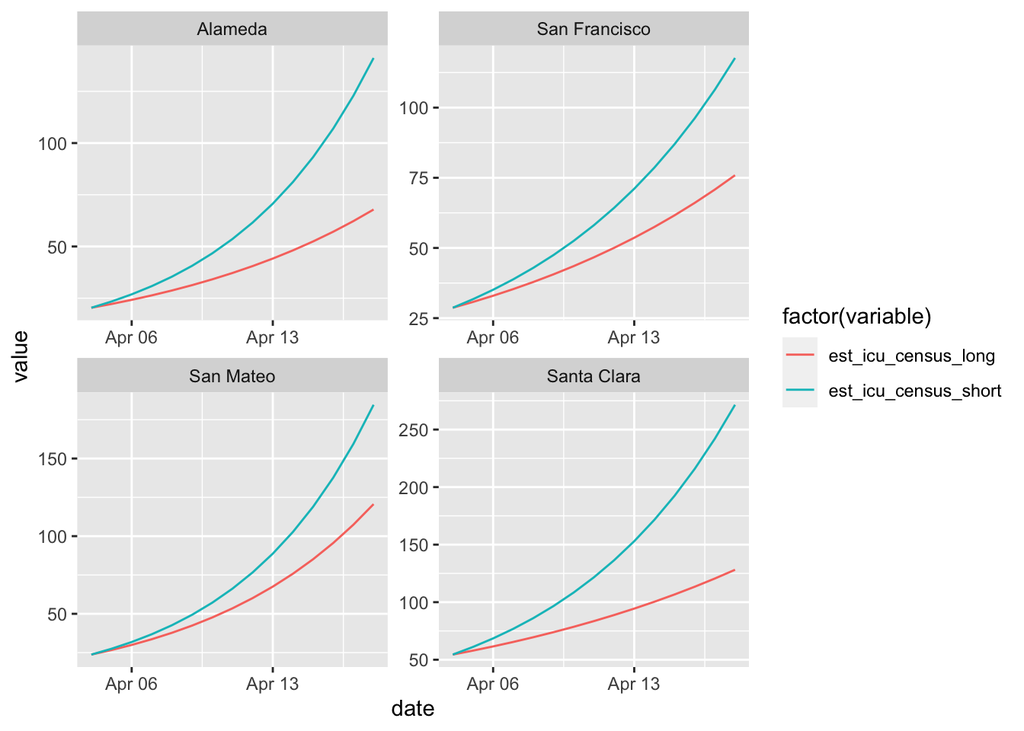

```r
ggplot(melt(long_dt[County %in% c('Alameda', 'Santa Clara', 'San Mateo', 'San Francisco'),
                    .(County, date, est_icu_census_long, est_icu_census_short)],
            id.vars = c('County', 'date')),
       aes(x=date, y=value, color=factor(variable))) + geom_line() +
       facet_wrap(~County, ncol=2, scales="free")
```

Create wide views with time series by county

First, ICU time series by county

```r
PROP_OF_AHA_BEDS_AVAILABLE = 0.3

icu_time_series_long = long_dt %>% group_by(County, date) %>%
  summarise(
    est_icu_beds_available = max(round(num_icu_beds * PROP_OF_AHA_BEDS_AVAILABLE)),
    icu_census_lb = round(est_icu_census_long),
    icu_census_m = round((est_icu_census_long+est_icu_census_short)/2),
    icu_census_ub = round(est_icu_census_short),
  ) %>% ungroup()

icu_time_series_long = icu_time_series_long %>% mutate(icu_census_str = paste0(icu_census_m, ' [', icu_census_lb, ', ', icu_census_ub, ']'))

# icu_time_series_long %>% filter(County == "Santa Clara")

wide_icu_str = as.data.table(dcast(icu_time_series_long, County + est_icu_beds_available ~ date, value.var = c('icu_census_str')))
wide_icu_str %>% kable() %>% kable_styling(bootstrap_options = c("striped", "hover"))
```

| County | est_icu_beds_available | 2020-04-04 | 2020-04-05 | 2020-04-06 | 2020-04-07 | 2020-04-08 | 2020-04-09 | 2020-04-10 | 2020-04-11 | 2020-04-12 | 2020-04-13 | 2020-04-14 | 2020-04-15 | 2020-04-16 | 2020-04-17 | 2020-04-18 |
| --- | --- | --- | --- | --- | --- | --- | --- | --- | --- | --- | --- | --- | --- | --- | --- | --- |
| Alameda | 51 | 20 [20, 20] | 23 [22, 23] | 26 [24, 27] | 29 [26, 31] | 32 [29, 35] | 36 [31, 41] | 40 [34, 47] | 45 [37, 54] | 51 [41, 62] | 57 [44, 71] | 65 [48, 81] | 73 [52, 93] | 82 [57, 107] | 93 [62, 123] | 105 [68, 141] |
| Butte | 13 | 1 [1, 1] | 1 [1, 1] | 1 [1, 2] | 2 [1, 2] | 2 [1, 2] | 2 [2, 3] | 3 [2, 3] | 3 [2, 4] | 3 [2, 5] | 4 [2, 6] | 4 [2, 7] | 5 [2, 8] | 6 [3, 10] | 7 [3, 11] | 8 [3, 14] |
| Contra Costa | 43 | 11 [11, 11] | 12 [12, 12] | 14 [14, 14] | 16 [16, 16] | 18 [18, 19] | 21 [20, 21] | 24 [23, 25] | 27 [26, 28] | 31 [30, 33] | 36 [34, 38] | 41 [39, 44] | 47 [45, 50] | 54 [51, 58] | 62 [58, 66] | 71 [66, 77] |
| El Dorado | 8 | 6 [6, 6] | 6 [6, 6] | 7 [7, 7] | 8 [7, 9] | 9 [8, 10] | 10 [8, 12] | 11 [9, 13] | 13 [10, 15] | 14 [11, 18] | 16 [11, 21] | 18 [12, 24] | 21 [14, 28] | 23 [15, 32] | 27 [16, 37] | 30 [17, 43] |
| Fresno | 66 | 5 [5, 5] | 6 [6, 6] | 7 [6, 7] | 8 [7, 8] | 9 [8, 10] | 11 [10, 12] | 13 [11, 15] | 15 [13, 18] | 18 [15, 21] | 21 [17, 26] | 25 [20, 31] | 30 [23, 37] | 35 [26, 45] | 42 [30, 54] | 50 [34, 65] |
| Humboldt | 7 | 0 [0, 0] | 0 [0, 0] | 1 [1, 1] | 1 [1, 1] | 1 [1, 1] | 1 [1, 1] | 1 [1, 1] | 1 [1, 1] | 1 [1, 1] | 2 [2, 2] | 2 [2, 2] | 2 [2, 2] | 3 [3, 3] | 3 [3, 3] | 4 [4, 3] |
| Imperial | 2 | 3 [3, 3] | 4 [4, 4] | 4 [4, 5] | 5 [4, 6] | 6 [5, 7] | 7 [5, 8] | 8 [6, 10] | 9 [7, 11] | 11 [8, 14] | 12 [8, 17] | 15 [9, 20] | 17 [10, 24] | 20 [12, 29] | 24 [13, 35] | 28 [14, 42] |
| Kern | 40 | 11 [11, 11] | 13 [13, 13] | 16 [17, 16] | 20 [21, 19] | 24 [26, 23] | 30 [32, 27] | 37 [40, 33] | 45 [50, 40] | 55 [62, 48] | 68 [78, 58] | 83 [97, 69] | 102 [120, 84] | 125 [150, 101] | 154 [187, 122] | 190 [233, 147] |
| Los Angeles | 548 | 347 [347, 347] | 410 [406, 414] | 485 [476, 495] | 574 [557, 591] | 679 [652, 705] | 803 [764, 842] | 950 [895, 1006] | 1124 [1048, 1201] | 1330 [1227, 1434] | 1574 [1436, 1712] | 1863 [1682, 2045] | 2206 [1970, 2441] | 2611 [2306, 2915] | 3091 [2701, 3481] | 3659 [3162, 4156] |
| Marin | 10 | 2 [2, 2] | 2 [2, 2] | 2 [2, 2] | 3 [2, 3] | 3 [2, 3] | 3 [3, 3] | 3 [3, 4] | 4 [3, 4] | 4 [3, 5] | 5 [3, 6] | 5 [4, 6] | 6 [4, 7] | 6 [4, 8] | 7 [4, 9] | 8 [5, 10] |
| Merced | 7 | 2 [2, 2] | 2 [2, 2] | 2 [2, 2] | 3 [3, 3] | 3 [3, 4] | 4 [3, 4] | 5 [4, 5] | 5 [4, 6] | 6 [5, 8] | 7 [6, 9] | 9 [7, 11] | 11 [8, 13] | 12 [9, 16] | 15 [10, 20] | 18 [11, 24] |
| Mono | 1 | 6 [6, 6] | 7 [7, 7] | 7 [7, 8] | 8 [8, 8] | 9 [9, 10] | 10 [9, 11] | 11 [10, 12] | 12 [11, 13] | 14 [12, 15] | 15 [13, 17] | 17 [15, 19] | 19 [16, 21] | 21 [18, 24] | 23 [19, 27] | 25 [21, 30] |
| Monterey | 13 | 6 [6, 6] | 6 [6, 7] | 7 [7, 8] | 8 [8, 9] | 9 [9, 10] | 11 [10, 12] | 12 [11, 14] | 14 [12, 16] | 16 [14, 18] | 18 [15, 21] | 21 [17, 25] | 24 [19, 28] | 27 [22, 33] | 31 [24, 38] | 36 [27, 44] |
| Napa | 20 | 0 [0, 0] | 0 [0, 0] | 0 [0, 1] | 1 [0, 1] | 1 [0, 1] | 1 [1, 1] | 1 [1, 1] | 1 [1, 1] | 1 [1, 1] | 1 [1, 1] | 1 [1, 2] | 1 [1, 2] | 1 [1, 2] | 2 [1, 2] | 2 [1, 3] |
| Nevada | 0 | 1 [1, 1] | 1 [1, 1] | 1 [1, 1] | 1 [1, 1] | 1 [1, 1] | 2 [1, 2] | 2 [2, 2] | 2 [2, 2] | 2 [2, 2] | 3 [2, 3] | 3 [3, 3] | 3 [3, 4] | 4 [3, 4] | 4 [4, 5] | 5 [4, 6] |
| Orange | 132 | 50 [50, 50] | 57 [56, 58] | 65 [62, 67] | 74 [70, 78] | 84 [78, 90] | 96 [87, 105] | 109 [97, 121] | 124 [108, 140] | 141 [120, 162] | 161 [134, 188] | 184 [150, 218] | 210 [167, 252] | 239 [186, 292] | 273 [208, 338] | 312 [232, 391] |
| Placer | 6 | 9 [9, 9] | 10 [10, 10] | 12 [11, 12] | 13 [12, 14] | 15 [14, 17] | 17 [15, 20] | 20 [17, 23] | 23 [19, 27] | 27 [21, 32] | 31 [24, 38] | 36 [26, 45] | 41 [29, 53] | 47 [33, 62] | 55 [37, 73] | 63 [41, 86] |
| Riverside | 84 | 45 [45, 45] | 53 [54, 53] | 63 [65, 61] | 74 [78, 71] | 88 [94, 82] | 103 [112, 95] | 122 [134, 110] | 144 [161, 127] | 170 [193, 148] | 201 [231, 171] | 238 [277, 198] | 281 [332, 230] | 332 [398, 266] | 393 [477, 308] | 465 [572, 357] |
| Sacramento | 71 | 24 [24, 24] | 28 [27, 28] | 32 [31, 32] | 36 [36, 37] | 42 [41, 42] | 48 [46, 49] | 55 [53, 57] | 63 [60, 65] | 72 [69, 75] | 83 [79, 87] | 95 [90, 100] | 109 [102, 116] | 125 [117, 134] | 144 [133, 154] | 165 [152, 178] |
| San Benito | 2 | 1 [1, 1] | 1 [1, 1] | 1 [1, 1] | 1 [1, 1] | 1 [1, 1] | 1 [1, 1] | 1 [1, 2] | 1 [1, 2] | 2 [1, 2] | 2 [1, 3] | 2 [1, 3] | 2 [1, 4] | 3 [1, 4] | 3 [2, 5] | 4 [2, 6] |
| San Bernardino | 111 | 45 [45, 45] | 57 [58, 55] | 72 [76, 67] | 91 [100, 83] | 116 [131, 102] | 148 [171, 125] | 189 [224, 153] | 241 [293, 188] | 307 [383, 231] | 392 [501, 284] | 502 [655, 348] | 643 [857, 428] | 823 [1122, 525] | 1056 [1467, 645] | 1355 [1919, 792] |
| San Diego | 152 | 62 [62, 62] | 72 [71, 73] | 84 [83, 86] | 98 [95, 101] | 115 [110, 120] | 134 [127, 141] | 157 [147, 166] | 183 [170, 196] | 214 [196, 232] | 250 [227, 273] | 292 [262, 322] | 341 [303, 380] | 399 [350, 448] | 466 [404, 528] | 545 [467, 623] |
| San Francisco | 64 | 29 [29, 29] | 31 [31, 32] | 34 [33, 35] | 37 [35, 39] | 40 [38, 43] | 44 [41, 48] | 48 [44, 53] | 52 [47, 58] | 57 [50, 64] | 62 [54, 71] | 68 [57, 79] | 74 [62, 87] | 81 [66, 96] | 89 [71, 106] | 97 [76, 118] |
| San Joaquin | 10 | 15 [15, 15] | 16 [16, 17] | 18 [17, 19] | 20 [18, 22] | 22 [19, 25] | 24 [21, 28] | 27 [22, 32] | 30 [24, 37] | 33 [25, 42] | 37 [27, 47] | 42 [29, 54] | 46 [31, 62] | 52 [33, 70] | 58 [36, 80] | 65 [38, 91] |
| San Luis Obispo | 8 | 2 [2, 2] | 2 [2, 2] | 2 [2, 2] | 2 [2, 2] | 2 [2, 3] | 3 [2, 3] | 3 [2, 4] | 3 [2, 5] | 4 [2, 6] | 4 [2, 7] | 5 [2, 8] | 6 [2, 9] | 7 [2, 11] | 8 [2, 13] | 9 [3, 15] |
| San Mateo | 27 | 24 [24, 24] | 27 [27, 27] | 31 [30, 32] | 35 [34, 37] | 40 [38, 43] | 46 [42, 49] | 52 [48, 57] | 60 [54, 66] | 68 [60, 77] | 78 [68, 89] | 89 [76, 103] | 102 [85, 119] | 117 [96, 138] | 133 [107, 159] | 153 [121, 185] |
| Santa Barbara | 14 | 10 [10, 10] | 12 [12, 13] | 14 [14, 15] | 17 [16, 18] | 20 [18, 22] | 24 [20, 27] | 28 [23, 32] | 33 [27, 39] | 39 [31, 47] | 46 [35, 56] | 54 [40, 68] | 64 [46, 82] | 76 [52, 99] | 90 [60, 120] | 106 [68, 144] |
| Santa Clara | 80 | 54 [54, 54] | 60 [58, 61] | 65 [62, 69] | 71 [65, 77] | 78 [70, 86] | 85 [74, 97] | 94 [79, 108] | 103 [84, 122] | 113 [89, 136] | 124 [94, 153] | 136 [100, 172] | 150 [107, 192] | 165 [113, 216] | 181 [121, 242] | 200 [128, 272] |
| Santa Cruz | 2 | 1 [1, 1] | 2 [1, 2] | 2 [2, 2] | 2 [2, 2] | 2 [2, 2] | 2 [2, 3] | 3 [2, 3] | 3 [2, 4] | 3 [2, 4] | 4 [2, 5] | 4 [3, 6] | 5 [3, 6] | 5 [3, 7] | 6 [3, 8] | 7 [3, 10] |
| Shasta | 15 | 1 [1, 1] | 1 [1, 1] | 1 [1, 1] | 1 [2, 1] | 2 [2, 1] | 2 [3, 2] | 3 [3, 2] | 3 [4, 2] | 4 [6, 3] | 5 [7, 3] | 6 [9, 4] | 8 [12, 4] | 10 [15, 5] | 13 [19, 6] | 16 [25, 7] |
| Solano | 21 | 6 [6, 6] | 6 [6, 7] | 7 [7, 8] | 8 [8, 9] | 9 [8, 10] | 11 [9, 12] | 12 [10, 14] | 14 [11, 16] | 16 [13, 19] | 18 [14, 22] | 21 [15, 26] | 24 [17, 30] | 27 [19, 35] | 31 [21, 41] | 36 [23, 48] |
| Sonoma | 17 | 3 [3, 3] | 3 [3, 3] | 3 [3, 3] | 4 [3, 4] | 4 [3, 4] | 4 [4, 5] | 5 [4, 6] | 5 [4, 7] | 6 [5, 7] | 7 [5, 8] | 8 [5, 10] | 8 [6, 11] | 9 [6, 13] | 11 [7, 14] | 12 [7, 16] |
| Stanislaus | 16 | 10 [10, 10] | 12 [12, 12] | 14 [14, 15] | 17 [16, 18] | 20 [18, 22] | 23 [21, 26] | 28 [24, 31] | 33 [27, 38] | 38 [32, 45] | 45 [36, 54] | 54 [42, 65] | 63 [48, 78] | 75 [55, 94] | 89 [64, 113] | 105 [73, 136] |
| Tulare | 9 | 3 [3, 3] | 3 [3, 3] | 4 [4, 4] | 5 [5, 5] | 6 [6, 6] | 7 [7, 7] | 9 [9, 8] | 10 [11, 10] | 13 [13, 12] | 15 [16, 15] | 19 [20, 18] | 22 [24, 21] | 27 [29, 25] | 33 [35, 31] | 40 [43, 37] |
| Ventura | 16 | 7 [7, 7] | 9 [8, 9] | 10 [9, 11] | 11 [10, 13] | 13 [11, 15] | 15 [12, 18] | 17 [13, 22] | 20 [15, 26] | 24 [16, 31] | 27 [18, 37] | 32 [20, 44] | 37 [22, 52] | 43 [24, 63] | 51 [26, 75] | 59 [29, 89] |
| Yolo | 2 | 1 [1, 1] | 2 [1, 2] | 2 [2, 2] | 2 [2, 2] | 2 [2, 3] | 3 [2, 4] | 3 [2, 4] | 4 [2, 5] | 4 [2, 6] | 5 [3, 7] | 6 [3, 9] | 7 [3, 11] | 8 [3, 13] | 9 [3, 16] | 11 [3, 19] |
| Yuba | 7 | 1 [1, 1] | 1 [1, 1] | 1 [1, 1] | 1 [1, 1] | 1 [1, 1] | 1 [1, 2] | 1 [1, 2] | 2 [1, 2] | 2 [1, 3] | 2 [1, 3] | 3 [2, 4] | 3 [2, 4] | 3 [2, 5] | 4 [2, 6] | 5 [2, 7] |

Now create a version that just shows excess census over 30% of AHA ICU beds

```r
icu_time_series_long_f = icu_time_series_long %>%
  mutate(excess_demand = paste0(pmax(0, icu_census_m - est_icu_beds_available),
                                ' [', pmax(0, icu_census_lb - est_icu_beds_available), ', ',
                                icu_census_ub - est_icu_beds_available, ']')) %>%
  mutate(excess_demand = ifelse(icu_census_ub>est_icu_beds_available, excess_demand, NA))

wide_icu_excess_demand = as.data.table(dcast(icu_time_series_long_f, County + est_icu_beds_available ~ date, value.var = c('excess_demand')))
wide_icu_excess_demand %>% kable() %>% kable_styling(bootstrap_options = c("striped", "hover"))
```

| County | est_icu_beds_available | 2020-04-04 | 2020-04-05 | 2020-04-06 | 2020-04-07 | 2020-04-08 | 2020-04-09 | 2020-04-10 | 2020-04-11 | 2020-04-12 | 2020-04-13 | 2020-04-14 | 2020-04-15 | 2020-04-16 | 2020-04-17 | 2020-04-18 |
| --- | --- | --- | --- | --- | --- | --- | --- | --- | --- | --- | --- | --- | --- | --- | --- | --- |
| Alameda | 51 | NA | NA | NA | NA | NA | NA | NA | 0 [0, 3] | 0 [0, 11] | 6 [0, 20] | 14 [0, 30] | 22 [1, 42] | 31 [6, 56] | 42 [11, 72] | 54 [17, 90] |
| Butte | 13 | NA | NA | NA | NA | NA | NA | NA | NA | NA | NA | NA | NA | NA | NA | 0 [0, 1] |
| Contra Costa | 43 | NA | NA | NA | NA | NA | NA | NA | NA | NA | NA | 0 [0, 1] | 4 [2, 7] | 11 [8, 15] | 19 [15, 23] | 28 [23, 34] |
| El Dorado | 8 | NA | NA | NA | 0 [0, 1] | 1 [0, 2] | 2 [0, 4] | 3 [1, 5] | 5 [2, 7] | 6 [3, 10] | 8 [3, 13] | 10 [4, 16] | 13 [6, 20] | 15 [7, 24] | 19 [8, 29] | 22 [9, 35] |
| Fresno | 66 | NA | NA | NA | NA | NA | NA | NA | NA | NA | NA | NA | NA | NA | NA | NA |
| Humboldt | 7 | NA | NA | NA | NA | NA | NA | NA | NA | NA | NA | NA | NA | NA | NA | NA |
| Imperial | 2 | 1 [1, 1] | 2 [2, 2] | 2 [2, 3] | 3 [2, 4] | 4 [3, 5] | 5 [3, 6] | 6 [4, 8] | 7 [5, 9] | 9 [6, 12] | 10 [6, 15] | 13 [7, 18] | 15 [8, 22] | 18 [10, 27] | 22 [11, 33] | 26 [12, 40] |
| Kern | 40 | NA | NA | NA | NA | NA | NA | NA | NA | 15 [22, 8] | 28 [38, 18] | 43 [57, 29] | 62 [80, 44] | 85 [110, 61] | 114 [147, 82] | 150 [193, 107] |
| Los Angeles | 548 | NA | NA | NA | 26 [9, 43] | 131 [104, 157] | 255 [216, 294] | 402 [347, 458] | 576 [500, 653] | 782 [679, 886] | 1026 [888, 1164] | 1315 [1134, 1497] | 1658 [1422, 1893] | 2063 [1758, 2367] | 2543 [2153, 2933] | 3111 [2614, 3608] |
| Marin | 10 | NA | NA | NA | NA | NA | NA | NA | NA | NA | NA | NA | NA | NA | NA | NA |
| Merced | 7 | NA | NA | NA | NA | NA | NA | NA | NA | 0 [0, 1] | 0 [0, 2] | 2 [0, 4] | 4 [1, 6] | 5 [2, 9] | 8 [3, 13] | 11 [4, 17] |
| Mono | 1 | 5 [5, 5] | 6 [6, 6] | 6 [6, 7] | 7 [7, 7] | 8 [8, 9] | 9 [8, 10] | 10 [9, 11] | 11 [10, 12] | 13 [11, 14] | 14 [12, 16] | 16 [14, 18] | 18 [15, 20] | 20 [17, 23] | 22 [18, 26] | 24 [20, 29] |
| Monterey | 13 | NA | NA | NA | NA | NA | NA | 0 [0, 1] | 1 [0, 3] | 3 [1, 5] | 5 [2, 8] | 8 [4, 12] | 11 [6, 15] | 14 [9, 20] | 18 [11, 25] | 23 [14, 31] |
| Napa | 20 | NA | NA | NA | NA | NA | NA | NA | NA | NA | NA | NA | NA | NA | NA | NA |
| Nevada | 0 | 1 [1, 1] | 1 [1, 1] | 1 [1, 1] | 1 [1, 1] | 1 [1, 1] | 2 [1, 2] | 2 [2, 2] | 2 [2, 2] | 2 [2, 2] | 3 [2, 3] | 3 [3, 3] | 3 [3, 4] | 4 [3, 4] | 4 [4, 5] | 5 [4, 6] |
| Orange | 132 | NA | NA | NA | NA | NA | NA | NA | 0 [0, 8] | 9 [0, 30] | 29 [2, 56] | 52 [18, 86] | 78 [35, 120] | 107 [54, 160] | 141 [76, 206] | 180 [100, 259] |
| Placer | 6 | 3 [3, 3] | 4 [4, 4] | 6 [5, 6] | 7 [6, 8] | 9 [8, 11] | 11 [9, 14] | 14 [11, 17] | 17 [13, 21] | 21 [15, 26] | 25 [18, 32] | 30 [20, 39] | 35 [23, 47] | 41 [27, 56] | 49 [31, 67] | 57 [35, 80] |
| Riverside | 84 | NA | NA | NA | NA | NA | 19 [28, 11] | 38 [50, 26] | 60 [77, 43] | 86 [109, 64] | 117 [147, 87] | 154 [193, 114] | 197 [248, 146] | 248 [314, 182] | 309 [393, 224] | 381 [488, 273] |
| Sacramento | 71 | NA | NA | NA | NA | NA | NA | NA | NA | 1 [0, 4] | 12 [8, 16] | 24 [19, 29] | 38 [31, 45] | 54 [46, 63] | 73 [62, 83] | 94 [81, 107] |
| San Benito | 2 | NA | NA | NA | NA | NA | NA | NA | NA | NA | 0 [0, 1] | 0 [0, 1] | 0 [0, 2] | 1 [0, 2] | 1 [0, 3] | 2 [0, 4] |
| San Bernardino | 111 | NA | NA | NA | NA | NA | 37 [60, 14] | 78 [113, 42] | 130 [182, 77] | 196 [272, 120] | 281 [390, 173] | 391 [544, 237] | 532 [746, 317] | 712 [1011, 414] | 945 [1356, 534] | 1244 [1808, 681] |
| San Diego | 152 | NA | NA | NA | NA | NA | NA | 5 [0, 14] | 31 [18, 44] | 62 [44, 80] | 98 [75, 121] | 140 [110, 170] | 189 [151, 228] | 247 [198, 296] | 314 [252, 376] | 393 [315, 471] |
| San Francisco | 64 | NA | NA | NA | NA | NA | NA | NA | NA | NA | 0 [0, 7] | 4 [0, 15] | 10 [0, 23] | 17 [2, 32] | 25 [7, 42] | 33 [12, 54] |
| San Joaquin | 10 | 5 [5, 5] | 6 [6, 7] | 8 [7, 9] | 10 [8, 12] | 12 [9, 15] | 14 [11, 18] | 17 [12, 22] | 20 [14, 27] | 23 [15, 32] | 27 [17, 37] | 32 [19, 44] | 36 [21, 52] | 42 [23, 60] | 48 [26, 70] | 55 [28, 81] |
| San Luis Obispo | 8 | NA | NA | NA | NA | NA | NA | NA | NA | NA | NA | NA | 0 [0, 1] | 0 [0, 3] | 0 [0, 5] | 1 [0, 7] |
| San Mateo | 27 | NA | NA | 4 [3, 5] | 8 [7, 10] | 13 [11, 16] | 19 [15, 22] | 25 [21, 30] | 33 [27, 39] | 41 [33, 50] | 51 [41, 62] | 62 [49, 76] | 75 [58, 92] | 90 [69, 111] | 106 [80, 132] | 126 [94, 158] |
| Santa Barbara | 14 | NA | NA | 0 [0, 1] | 3 [2, 4] | 6 [4, 8] | 10 [6, 13] | 14 [9, 18] | 19 [13, 25] | 25 [17, 33] | 32 [21, 42] | 40 [26, 54] | 50 [32, 68] | 62 [38, 85] | 76 [46, 106] | 92 [54, 130] |
| Santa Clara | 80 | NA | NA | NA | NA | 0 [0, 6] | 5 [0, 17] | 14 [0, 28] | 23 [4, 42] | 33 [9, 56] | 44 [14, 73] | 56 [20, 92] | 70 [27, 112] | 85 [33, 136] | 101 [41, 162] | 120 [48, 192] |
| Santa Cruz | 2 | NA | NA | NA | NA | NA | 0 [0, 1] | 1 [0, 1] | 1 [0, 2] | 1 [0, 2] | 2 [0, 3] | 2 [1, 4] | 3 [1, 4] | 3 [1, 5] | 4 [1, 6] | 5 [1, 8] |
| Shasta | 15 | NA | NA | NA | NA | NA | NA | NA | NA | NA | NA | NA | NA | NA | NA | NA |
| Solano | 21 | NA | NA | NA | NA | NA | NA | NA | NA | NA | 0 [0, 1] | 0 [0, 5] | 3 [0, 9] | 6 [0, 14] | 10 [0, 20] | 15 [2, 27] |
| Sonoma | 17 | NA | NA | NA | NA | NA | NA | NA | NA | NA | NA | NA | NA | NA | NA | NA |
| Stanislaus | 16 | NA | NA | NA | 1 [0, 2] | 4 [2, 6] | 7 [5, 10] | 12 [8, 15] | 17 [11, 22] | 22 [16, 29] | 29 [20, 38] | 38 [26, 49] | 47 [32, 62] | 59 [39, 78] | 73 [48, 97] | 89 [57, 120] |
| Tulare | 9 | NA | NA | NA | NA | NA | NA | NA | 1 [2, 1] | 4 [4, 3] | 6 [7, 6] | 10 [11, 9] | 13 [15, 12] | 18 [20, 16] | 24 [26, 22] | 31 [34, 28] |
| Ventura | 16 | NA | NA | NA | NA | NA | 0 [0, 2] | 1 [0, 6] | 4 [0, 10] | 8 [0, 15] | 11 [2, 21] | 16 [4, 28] | 21 [6, 36] | 27 [8, 47] | 35 [10, 59] | 43 [13, 73] |
| Yolo | 2 | NA | NA | NA | NA | 0 [0, 1] | 1 [0, 2] | 1 [0, 2] | 2 [0, 3] | 2 [0, 4] | 3 [1, 5] | 4 [1, 7] | 5 [1, 9] | 6 [1, 11] | 7 [1, 14] | 9 [1, 17] |
| Yuba | 7 | NA | NA | NA | NA | NA | NA | NA | NA | NA | NA | NA | NA | NA | NA | NA |

Write the ICU tables to CSV for now

```r
fwrite(wide_icu_str, 'data/wide_icu_str_v5.csv')
fwrite(wide_icu_excess_demand, 'data/wide_icu_excess_demand_v5.csv')
```

And let’s do the same for Acute/Floor beds

```r
acute_time_series_long = long_dt %>% group_by(County, date) %>%
  summarise(
    est_floor_beds_available = max(round(num_acute_beds * PROP_OF_AHA_BEDS_AVAILABLE)),
    acute_census_lb = round(est_floor_census_long),
    acute_census_m = round((est_floor_census_long + est_floor_census_short)/2),
    acute_census_ub = round(est_floor_census_short),
  ) %>% ungroup()

acute_time_series_long = acute_time_series_long %>% mutate(acute_census_str = paste0(acute_census_m, ' [', acute_census_lb, ', ', acute_census_ub, ']'))

# acute_time_series_long %>% filter(County == "Santa Clara")

wide_acute_str = as.data.table(dcast(acute_time_series_long, County + est_floor_beds_available ~ date, value.var = c('acute_census_str')))
wide_acute_str %>% kable() %>% kable_styling(bootstrap_options = c("striped", "hover"))
```

| County | est_floor_beds_available | 2020-04-04 | 2020-04-05 | 2020-04-06 | 2020-04-07 | 2020-04-08 | 2020-04-09 | 2020-04-10 | 2020-04-11 | 2020-04-12 | 2020-04-13 | 2020-04-14 | 2020-04-15 | 2020-04-16 | 2020-04-17 | 2020-04-18 |
| --- | --- | --- | --- | --- | --- | --- | --- | --- | --- | --- | --- | --- | --- | --- | --- | --- |
| Alameda | 269 | 40 [40, 40] | 44 [43, 46] | 50 [47, 52] | 56 [51, 60] | 62 [56, 69] | 70 [61, 79] | 79 [66, 91] | 88 [72, 104] | 99 [79, 120] | 112 [86, 138] | 126 [94, 158] | 142 [102, 181] | 160 [111, 208] | 180 [121, 239] | 203 [132, 275] |
| Butte | 87 | 2 [2, 2] | 2 [2, 2] | 2 [2, 3] | 3 [2, 3] | 3 [2, 4] | 4 [3, 5] | 4 [3, 5] | 5 [3, 6] | 5 [3, 8] | 6 [3, 9] | 7 [4, 11] | 8 [4, 13] | 10 [4, 16] | 12 [4, 19] | 13 [5, 22] |
| Contra Costa | 209 | 19 [19, 19] | 22 [22, 22] | 25 [25, 26] | 29 [29, 30] | 33 [33, 34] | 38 [37, 39] | 44 [43, 45] | 50 [48, 52] | 58 [55, 60] | 66 [63, 69] | 76 [72, 80] | 87 [82, 92] | 99 [93, 106] | 114 [106, 122] | 131 [121, 140] |
| El Dorado | 35 | 9 [9, 9] | 11 [10, 11] | 12 [11, 13] | 13 [12, 15] | 15 [13, 17] | 17 [14, 20] | 19 [15, 23] | 22 [17, 26] | 24 [18, 31] | 28 [20, 35] | 31 [21, 41] | 35 [23, 47] | 40 [25, 55] | 45 [27, 64] | 52 [30, 74] |
| Fresno | 258 | 9 [9, 9] | 11 [11, 11] | 13 [12, 13] | 15 [14, 16] | 18 [16, 19] | 21 [19, 23] | 25 [21, 28] | 29 [25, 34] | 34 [28, 41] | 41 [32, 49] | 48 [37, 59] | 57 [43, 71] | 67 [49, 86] | 80 [57, 103] | 95 [65, 124] |
| Humboldt | 38 | 1 [1, 1] | 1 [1, 1] | 1 [1, 1] | 1 [1, 1] | 1 [1, 1] | 1 [1, 1] | 2 [2, 2] | 2 [2, 2] | 2 [2, 2] | 3 [3, 3] | 3 [3, 3] | 4 [4, 4] | 5 [5, 4] | 5 [5, 5] | 6 [6, 6] |
| Imperial | 14 | 6 [6, 6] | 7 [6, 7] | 8 [7, 8] | 9 [8, 10] | 11 [9, 12] | 12 [10, 15] | 14 [11, 18] | 17 [12, 21] | 20 [14, 25] | 23 [15, 30] | 27 [17, 37] | 32 [19, 44] | 37 [21, 53] | 44 [24, 64] | 51 [27, 76] |
| Kern | 202 | 22 [22, 22] | 27 [28, 27] | 33 [35, 32] | 41 [43, 39] | 50 [54, 47] | 62 [67, 57] | 76 [83, 68] | 93 [103, 82] | 114 [129, 99] | 140 [160, 119] | 172 [200, 144] | 211 [249, 173] | 259 [310, 209] | 319 [386, 251] | 392 [481, 303] |
| Los Angeles | 2690 | 660 [660, 660] | 780 [773, 788] | 923 [905, 941] | 1092 [1060, 1124] | 1291 [1241, 1342] | 1528 [1453, 1602] | 1807 [1701, 1913] | 2138 [1992, 2284] | 2530 [2333, 2727] | 2994 [2732, 3257] | 3544 [3199, 3889] | 4195 [3746, 4643] | 4965 [4386, 5544] | 5878 [5136, 6620] | 6960 [6015, 7905] |
| Marin | 89 | 3 [3, 3] | 3 [3, 3] | 4 [4, 4] | 4 [4, 4] | 5 [4, 5] | 5 [4, 6] | 5 [5, 6] | 6 [5, 7] | 7 [5, 8] | 7 [6, 9] | 8 [6, 10] | 9 [6, 12] | 10 [7, 13] | 11 [7, 15] | 12 [8, 17] |
| Merced | 49 | 3 [3, 3] | 4 [4, 4] | 5 [4, 5] | 5 [5, 6] | 6 [6, 7] | 8 [7, 9] | 9 [8, 10] | 11 [9, 13] | 13 [10, 15] | 15 [11, 18] | 18 [13, 22] | 21 [15, 27] | 25 [17, 32] | 29 [20, 39] | 35 [23, 47] |
| Mono | 4 | 14 [14, 14] | 15 [15, 16] | 17 [17, 18] | 19 [18, 20] | 21 [20, 22] | 23 [22, 25] | 26 [24, 28] | 29 [26, 31] | 32 [28, 35] | 35 [31, 39] | 39 [34, 44] | 43 [37, 49] | 48 [41, 55] | 53 [44, 62] | 59 [48, 70] |
| Monterey | 106 | 10 [10, 10] | 12 [12, 12] | 13 [13, 14] | 15 [15, 16] | 17 [16, 19] | 20 [18, 22] | 23 [20, 25] | 26 [23, 29] | 30 [25, 34] | 34 [29, 39] | 39 [32, 45] | 44 [36, 52] | 50 [40, 61] | 58 [45, 70] | 66 [50, 82] |
| Napa | 47 | 1 [1, 1] | 1 [1, 1] | 1 [1, 1] | 1 [1, 1] | 1 [1, 1] | 1 [1, 1] | 1 [1, 1] | 1 [1, 2] | 2 [1, 2] | 2 [1, 2] | 2 [1, 3] | 2 [1, 3] | 2 [1, 3] | 3 [2, 4] | 3 [2, 5] |
| Nevada | 0 | 1 [1, 1] | 1 [1, 1] | 2 [2, 2] | 2 [2, 2] | 2 [2, 2] | 2 [2, 2] | 3 [2, 3] | 3 [3, 3] | 3 [3, 4] | 4 [3, 4] | 4 [4, 5] | 5 [4, 6] | 6 [5, 6] | 6 [5, 7] | 7 [6, 8] |
| Orange | 721 | 93 [93, 93] | 105 [104, 107] | 120 [115, 124] | 136 [129, 144] | 155 [144, 167] | 177 [160, 193] | 201 [179, 224] | 229 [199, 259] | 261 [223, 300] | 298 [248, 347] | 340 [277, 402] | 387 [309, 466] | 442 [345, 540] | 505 [384, 625] | 576 [429, 723] |
| Placer | 44 | 14 [14, 14] | 16 [16, 17] | 19 [18, 20] | 22 [20, 23] | 25 [22, 27] | 28 [25, 32] | 33 [28, 38] | 38 [31, 45] | 44 [34, 53] | 50 [38, 62] | 58 [43, 73] | 67 [48, 86] | 77 [53, 101] | 89 [60, 119] | 103 [66, 140] |
| Riverside | 475 | 83 [83, 83] | 97 [99, 96] | 115 [119, 111] | 135 [142, 129] | 160 [170, 149] | 188 [204, 173] | 222 [245, 200] | 263 [293, 232] | 310 [352, 269] | 366 [421, 311] | 433 [505, 361] | 512 [605, 418] | 605 [725, 485] | 715 [869, 562] | 846 [1042, 651] |
| Sacramento | 327 | 45 [45, 45] | 52 [51, 52] | 59 [59, 60] | 68 [67, 69] | 78 [76, 80] | 90 [87, 92] | 103 [99, 106] | 118 [113, 123] | 135 [129, 141] | 155 [148, 163] | 178 [168, 188] | 205 [192, 217] | 235 [219, 251] | 270 [250, 289] | 310 [286, 334] |
| San Benito | 10 | 1 [1, 1] | 1 [1, 2] | 2 [2, 2] | 2 [2, 2] | 2 [2, 2] | 2 [2, 3] | 3 [2, 3] | 3 [2, 4] | 3 [2, 4] | 4 [2, 5] | 4 [3, 6] | 5 [3, 7] | 6 [3, 8] | 6 [3, 10] | 7 [3, 11] |
| San Bernardino | 521 | 93 [93, 93] | 118 [122, 115] | 150 [160, 141] | 191 [209, 173] | 243 [273, 212] | 309 [357, 260] | 394 [467, 320] | 502 [611, 393] | 641 [800, 482] | 819 [1046, 592] | 1047 [1368, 727] | 1341 [1789, 893] | 1718 [2340, 1096] | 2204 [3061, 1346] | 2829 [4004, 1653] |
| San Diego | 757 | 115 [115, 115] | 134 [133, 136] | 157 [154, 160] | 183 [178, 189] | 214 [205, 223] | 250 [237, 263] | 292 [274, 310] | 341 [316, 365] | 398 [366, 431] | 465 [422, 508] | 544 [488, 600] | 635 [564, 707] | 743 [651, 834] | 868 [753, 984] | 1015 [870, 1160] |
| San Francisco | 231 | 51 [51, 51] | 56 [55, 57] | 61 [59, 63] | 66 [63, 69] | 72 [68, 77] | 79 [73, 85] | 86 [78, 94] | 94 [83, 104] | 102 [89, 115] | 111 [96, 127] | 122 [103, 141] | 133 [110, 155] | 145 [118, 172] | 158 [127, 190] | 173 [136, 210] |
| San Joaquin | 51 | 28 [28, 28] | 31 [30, 32] | 35 [32, 37] | 38 [35, 42] | 42 [37, 48] | 47 [40, 54] | 52 [43, 62] | 58 [46, 71] | 65 [49, 81] | 72 [52, 92] | 80 [56, 105] | 90 [60, 119] | 100 [64, 136] | 112 [69, 155] | 125 [74, 176] |
| San Luis Obispo | 49 | 2 [2, 2] | 3 [3, 3] | 3 [3, 3] | 3 [3, 4] | 4 [3, 5] | 4 [3, 6] | 5 [3, 7] | 5 [3, 8] | 6 [3, 9] | 7 [3, 11] | 8 [4, 13] | 9 [4, 15] | 11 [4, 17] | 12 [4, 20] | 14 [4, 24] |
| San Mateo | 168 | 42 [42, 42] | 48 [47, 49] | 55 [53, 57] | 63 [60, 66] | 72 [67, 76] | 82 [76, 88] | 93 [85, 102] | 107 [95, 118] | 122 [107, 136] | 139 [120, 158] | 159 [135, 183] | 182 [152, 212] | 208 [170, 245] | 238 [191, 284] | 272 [215, 329] |
| Santa Barbara | 51 | 18 [18, 18] | 21 [20, 21] | 24 [23, 26] | 29 [26, 31] | 34 [30, 37] | 40 [34, 45] | 47 [39, 54] | 55 [45, 65] | 65 [51, 79] | 77 [59, 95] | 91 [67, 115] | 108 [77, 138] | 127 [88, 167] | 151 [101, 201] | 179 [115, 242] |
| Santa Clara | 395 | 105 [105, 105] | 114 [111, 117] | 125 [118, 131] | 137 [126, 147] | 149 [133, 165] | 164 [142, 186] | 179 [151, 208] | 197 [160, 233] | 216 [170, 262] | 237 [181, 294] | 261 [193, 329] | 287 [205, 369] | 316 [218, 414] | 348 [231, 464] | 383 [246, 521] |
| Santa Cruz | 20 | 3 [3, 3] | 3 [3, 3] | 3 [3, 3] | 4 [3, 4] | 4 [3, 5] | 4 [4, 5] | 5 [4, 6] | 5 [4, 7] | 6 [4, 8] | 7 [5, 9] | 8 [5, 10] | 9 [5, 12] | 10 [6, 14] | 11 [6, 16] | 12 [6, 18] |
| Shasta | 87 | 1 [1, 1] | 2 [2, 1] | 2 [2, 2] | 2 [3, 2] | 3 [3, 2] | 3 [4, 3] | 4 [5, 3] | 5 [7, 4] | 7 [9, 4] | 8 [11, 5] | 10 [15, 6] | 13 [19, 7] | 16 [24, 8] | 20 [31, 10] | 25 [39, 11] |
| Solano | 94 | 10 [10, 10] | 12 [12, 12] | 13 [13, 14] | 15 [14, 17] | 17 [16, 19] | 20 [17, 22] | 23 [19, 26] | 26 [21, 31] | 30 [24, 36] | 34 [26, 42] | 39 [29, 49] | 44 [32, 57] | 51 [35, 66] | 58 [39, 77] | 67 [43, 90] |
| Sonoma | 113 | 4 [4, 4] | 5 [5, 5] | 5 [5, 6] | 6 [6, 7] | 7 [6, 7] | 7 [6, 9] | 8 [7, 10] | 9 [7, 11] | 10 [8, 13] | 12 [9, 14] | 13 [9, 17] | 14 [10, 19] | 16 [11, 21] | 18 [12, 25] | 20 [12, 28] |
| Stanislaus | 108 | 20 [20, 20] | 23 [23, 24] | 27 [26, 28] | 32 [30, 34] | 38 [34, 41] | 45 [40, 49] | 53 [46, 59] | 62 [52, 72] | 73 [60, 86] | 86 [69, 103] | 102 [80, 124] | 121 [92, 150] | 143 [106, 180] | 169 [121, 216] | 200 [140, 260] |
| Tulare | 101 | 5 [5, 5] | 6 [6, 6] | 8 [8, 8] | 9 [10, 9] | 11 [12, 11] | 14 [14, 13] | 17 [17, 16] | 20 [21, 20] | 25 [26, 24] | 30 [31, 28] | 36 [38, 34] | 44 [47, 41] | 53 [57, 50] | 65 [69, 60] | 78 [84, 72] |
| Ventura | 43 | 14 [14, 14] | 16 [15, 16] | 18 [16, 19] | 21 [18, 23] | 24 [20, 28] | 27 [22, 33] | 32 [24, 39] | 37 [27, 47] | 43 [29, 56] | 50 [32, 67] | 58 [36, 80] | 67 [39, 95] | 79 [43, 114] | 92 [48, 136] | 107 [53, 162] |
| Yolo | 15 | 3 [3, 3] | 3 [3, 3] | 3 [3, 4] | 4 [3, 5] | 4 [3, 5] | 5 [4, 7] | 6 [4, 8] | 7 [4, 10] | 8 [4, 12] | 9 [5, 14] | 11 [5, 17] | 13 [5, 20] | 15 [6, 24] | 18 [6, 29] | 21 [7, 35] |
| Yuba | 52 | 1 [1, 1] | 2 [1, 2] | 2 [2, 2] | 2 [2, 2] | 2 [2, 3] | 3 [2, 3] | 3 [2, 4] | 3 [2, 4] | 4 [3, 5] | 4 [3, 6] | 5 [3, 7] | 6 [3, 8] | 7 [4, 10] | 8 [4, 12] | 9 [4, 14] |

```r
acute_time_series_long_f = acute_time_series_long %>%
  mutate(excess_demand = paste0(pmax(0, acute_census_m - est_floor_beds_available),
                                ' [', pmax(0, acute_census_lb - est_floor_beds_available), ', ',
                                acute_census_ub - est_floor_beds_available, ']')) %>%
  mutate(excess_demand = ifelse(acute_census_ub > est_floor_beds_available, excess_demand, NA))

wide_acute_excess_demand = as.data.table(dcast(acute_time_series_long_f, County + est_floor_beds_available ~ date, value.var = c('excess_demand')))
wide_acute_excess_demand %>% kable() %>% kable_styling(bootstrap_options = c("striped", "hover"))
```

| County | est_floor_beds_available | 2020-04-04 | 2020-04-05 | 2020-04-06 | 2020-04-07 | 2020-04-08 | 2020-04-09 | 2020-04-10 | 2020-04-11 | 2020-04-12 | 2020-04-13 | 2020-04-14 | 2020-04-15 | 2020-04-16 | 2020-04-17 | 2020-04-18 |
| --- | --- | --- | --- | --- | --- | --- | --- | --- | --- | --- | --- | --- | --- | --- | --- | --- |
| Alameda | 269 | NA | NA | NA | NA | NA | NA | NA | NA | NA | NA | NA | NA | NA | NA | 0 [0, 6] |
| Butte | 87 | NA | NA | NA | NA | NA | NA | NA | NA | NA | NA | NA | NA | NA | NA | NA |
| Contra Costa | 209 | NA | NA | NA | NA | NA | NA | NA | NA | NA | NA | NA | NA | NA | NA | NA |
| El Dorado | 35 | NA | NA | NA | NA | NA | NA | NA | NA | NA | NA | 0 [0, 6] | 0 [0, 12] | 5 [0, 20] | 10 [0, 29] | 17 [0, 39] |
| Fresno | 258 | NA | NA | NA | NA | NA | NA | NA | NA | NA | NA | NA | NA | NA | NA | NA |
| Humboldt | 38 | NA | NA | NA | NA | NA | NA | NA | NA | NA | NA | NA | NA | NA | NA | NA |
| Imperial | 14 | NA | NA | NA | NA | NA | 0 [0, 1] | 0 [0, 4] | 3 [0, 7] | 6 [0, 11] | 9 [1, 16] | 13 [3, 23] | 18 [5, 30] | 23 [7, 39] | 30 [10, 50] | 37 [13, 62] |
| Kern | 202 | NA | NA | NA | NA | NA | NA | NA | NA | NA | NA | NA | NA | 57 [108, 7] | 117 [184, 49] | 190 [279, 101] |
| Los Angeles | 2690 | NA | NA | NA | NA | NA | NA | NA | NA | 0 [0, 37] | 304 [42, 567] | 854 [509, 1199] | 1505 [1056, 1953] | 2275 [1696, 2854] | 3188 [2446, 3930] | 4270 [3325, 5215] |
| Marin | 89 | NA | NA | NA | NA | NA | NA | NA | NA | NA | NA | NA | NA | NA | NA | NA |
| Merced | 49 | NA | NA | NA | NA | NA | NA | NA | NA | NA | NA | NA | NA | NA | NA | NA |
| Mono | 4 | 10 [10, 10] | 11 [11, 12] | 13 [13, 14] | 15 [14, 16] | 17 [16, 18] | 19 [18, 21] | 22 [20, 24] | 25 [22, 27] | 28 [24, 31] | 31 [27, 35] | 35 [30, 40] | 39 [33, 45] | 44 [37, 51] | 49 [40, 58] | 55 [44, 66] |
| Monterey | 106 | NA | NA | NA | NA | NA | NA | NA | NA | NA | NA | NA | NA | NA | NA | NA |
| Napa | 47 | NA | NA | NA | NA | NA | NA | NA | NA | NA | NA | NA | NA | NA | NA | NA |
| Nevada | 0 | 1 [1, 1] | 1 [1, 1] | 2 [2, 2] | 2 [2, 2] | 2 [2, 2] | 2 [2, 2] | 3 [2, 3] | 3 [3, 3] | 3 [3, 4] | 4 [3, 4] | 4 [4, 5] | 5 [4, 6] | 6 [5, 6] | 6 [5, 7] | 7 [6, 8] |
| Orange | 721 | NA | NA | NA | NA | NA | NA | NA | NA | NA | NA | NA | NA | NA | NA | 0 [0, 2] |
| Placer | 44 | NA | NA | NA | NA | NA | NA | NA | 0 [0, 1] | 0 [0, 9] | 6 [0, 18] | 14 [0, 29] | 23 [4, 42] | 33 [9, 57] | 45 [16, 75] | 59 [22, 96] |
| Riverside | 475 | NA | NA | NA | NA | NA | NA | NA | NA | NA | NA | NA | NA | 130 [250, 10] | 240 [394, 87] | 371 [567, 176] |
| Sacramento | 327 | NA | NA | NA | NA | NA | NA | NA | NA | NA | NA | NA | NA | NA | NA | 0 [0, 7] |
| San Benito | 10 | NA | NA | NA | NA | NA | NA | NA | NA | NA | NA | NA | NA | NA | NA | 0 [0, 1] |
| San Bernardino | 521 | NA | NA | NA | NA | NA | NA | NA | NA | NA | 298 [525, 71] | 526 [847, 206] | 820 [1268, 372] | 1197 [1819, 575] | 1683 [2540, 825] | 2308 [3483, 1132] |
| San Diego | 757 | NA | NA | NA | NA | NA | NA | NA | NA | NA | NA | NA | NA | 0 [0, 77] | 111 [0, 227] | 258 [113, 403] |
| San Francisco | 231 | NA | NA | NA | NA | NA | NA | NA | NA | NA | NA | NA | NA | NA | NA | NA |
| San Joaquin | 51 | NA | NA | NA | NA | NA | 0 [0, 3] | 1 [0, 11] | 7 [0, 20] | 14 [0, 30] | 21 [1, 41] | 29 [5, 54] | 39 [9, 68] | 49 [13, 85] | 61 [18, 104] | 74 [23, 125] |
| San Luis Obispo | 49 | NA | NA | NA | NA | NA | NA | NA | NA | NA | NA | NA | NA | NA | NA | NA |
| San Mateo | 168 | NA | NA | NA | NA | NA | NA | NA | NA | NA | NA | 0 [0, 15] | 14 [0, 44] | 40 [2, 77] | 70 [23, 116] | 104 [47, 161] |
| Santa Barbara | 51 | NA | NA | NA | NA | NA | NA | 0 [0, 3] | 4 [0, 14] | 14 [0, 28] | 26 [8, 44] | 40 [16, 64] | 57 [26, 87] | 76 [37, 116] | 100 [50, 150] | 128 [64, 191] |
| Santa Clara | 395 | NA | NA | NA | NA | NA | NA | NA | NA | NA | NA | NA | NA | 0 [0, 19] | 0 [0, 69] | 0 [0, 126] |
| Santa Cruz | 20 | NA | NA | NA | NA | NA | NA | NA | NA | NA | NA | NA | NA | NA | NA | NA |
| Shasta | 87 | NA | NA | NA | NA | NA | NA | NA | NA | NA | NA | NA | NA | NA | NA | NA |
| Solano | 94 | NA | NA | NA | NA | NA | NA | NA | NA | NA | NA | NA | NA | NA | NA | NA |
| Sonoma | 113 | NA | NA | NA | NA | NA | NA | NA | NA | NA | NA | NA | NA | NA | NA | NA |
| Stanislaus | 108 | NA | NA | NA | NA | NA | NA | NA | NA | NA | NA | 0 [0, 16] | 13 [0, 42] | 35 [0, 72] | 61 [13, 108] | 92 [32, 152] |
| Tulare | 101 | NA | NA | NA | NA | NA | NA | NA | NA | NA | NA | NA | NA | NA | NA | NA |
| Ventura | 43 | NA | NA | NA | NA | NA | NA | NA | 0 [0, 4] | 0 [0, 13] | 7 [0, 24] | 15 [0, 37] | 24 [0, 52] | 36 [0, 71] | 49 [5, 93] | 64 [10, 119] |
| Yolo | 15 | NA | NA | NA | NA | NA | NA | NA | NA | NA | NA | 0 [0, 2] | 0 [0, 5] | 0 [0, 9] | 3 [0, 14] | 6 [0, 20] |
| Yuba | 52 | NA | NA | NA | NA | NA | NA | NA | NA | NA | NA | NA | NA | NA | NA | NA |

```r
fwrite(wide_acute_str, 'data/wide_acute_str_v5.csv')
fwrite(wide_acute_excess_demand, 'data/wide_acute_excess_demand_v5.csv')
```